# Creative Gaming

Section 81

Dain Hall

Trevor Cornell

# Preliminaries

### Determine notebook defaults:

### Load packages:

### Read in the data:

```r
# use load("filename.Rdata") for .Rdata files
# rm(list=ls())
load("/Users/dain/Programs/R_Projects/MKTG_482_HW4/creative_gaming.Rdata")
```

# Assignment answers

Questions: 1. How to convert csv -> Rdata? 2. How to set up Rdata into multiple importable variables (like this project)? 3. How come we’re using the same data for nnet for training & testing? 4. How are my convert & predicted convert using the models so far off?

## Part 1: Exploratory Analytics

First, to gain an understanding of whether the data is appropriate for predictive analytics, you decide to engage in some exploratory analytics. Please answer the following questions:

Hint: install the “skimr” package and use the “skim_without_charts()” command (don’t forget to add library(skimr) in the header of your Rmd file). Don’t worry about formatting when you knit to pdf.

1. What is the organic probability of converting to Zalon?

```r
paste("OrganicProb(convert): ", percent(mean(cg_organic$converted), 0.01))
```

```
[1] "OrganicProb(convert):  5.75%"
```

2. For each feature, show basic summary statistics.

```r
skim_without_charts(cg_organic)
```

```
── Data Summary ────────────────────────
                           Values
Name                       cg_organic
Number of rows             30000
Number of columns          20
_______________________
Column type frequency:
  factor                   6
  numeric                  14
________________________
Group variables            None

── Variable type: factor ────────────────────────────────────────────────────────────────────────────────────────────────
  skim_variable          n_missing complete_rate ordered n_unique top_counts
1 AcquiredSpaceship              0             1 FALSE          2 0: 21695, 1: 8305
2 AcquiredIonWeapon              0             1 FALSE          2 0: 29439, 1: 561
3 PurchasedCoinPackSmall         0             1 FALSE          2 0: 19857, 1: 10143
4 PurchasedCoinPackLarge         0             1 FALSE          2 0: 22061, 1: 7939
5 UserNoConsole                  0             1 FALSE          2 0: 24546, 1: 5454
6 UserHasOldOS                   0             1 FALSE          2 0: 27411, 1: 2589

── Variable type: numeric ───────────────────────────────────────────────────────────────────────────────────────────────
   skim_variable           n_missing complete_rate      mean      sd    p0   p25   p50   p75  p100
 1 converted                       0             1    0.0575   0.233     0     0     0     0     1
 2 GameLevel                       0             1    6.25     2.77      1     4     7     9    10
 3 NumGameDays                     0             1   12.2      7.10      1     6    13    18    28
 4 NumGameDays4Plus                0             1    1.26     3.19      0     0     0     0    24
 5 NumInGameMessagesSent           0             1   73.8    107.        0     0    26   112  1227
 6 NumSpaceHeroBadges              0             1    0.444    1.52      0     0     0     0    12
 7 NumFriendRequestIgnored         0             1   29.6     34.0       0     0    16    53   121
 8 NumFriends                      0             1   47.7     94.3       0     0     5    43   486
 9 TimesLostSpaceship              0             1    4.44    11.5       0     0     0     4   298
10 TimesKilled                     0             1    0.293    3.42      0     0     0     0   178
11 TimesCaptain                    0             1    1.58     8.77      0     0     0     0   429
12 TimesNavigator                  0             1    1.40     7.95      0     0     0     0   545
13 NumAdsClicked                   0             1    9.49     7.40      0     4     8    12    38
14 DaysUser                        0             1 2626.     661.      244  2162  2557  3105  4139
```

## Part 2: Predictive Model

1. Create a training and test sample based on the “cg_organic” dataframe. Please use the “sample_train_org” vector to select observations for both new dataframes. You can use this syntax:

| variable | factor | var_imp | var_imp_lower | var_imp_upper | p_value |
| --- | --- | --- | --- | --- | --- |
| NumSpaceHeroBadges | No | 1.28012 | 1.2016 | 1.35862 | 0.000 |
| TimesLostSpaceship | No | -0.91013 | -1.1440 | -0.67625 | 0.000 |
| NumFriendRequestIgnored | No | -0.80461 | -0.9764 | -0.63284 | 0.000 |
| GameLevel | No | 0.57684 | 0.4236 | 0.73004 | 0.000 |
| AcquiredSpaceship1 | Yes | 0.53822 | 0.3973 | 0.67912 | 0.000 |
| AcquiredIonWeapon1 | Yes | 0.47795 | 0.0798 | 0.87608 | 0.019 |
| NumGameDays | No | 0.46940 | 0.3175 | 0.62126 | 0.000 |
| NumAdsClicked | No | 0.39750 | 0.2890 | 0.50597 | 0.000 |
| TimesNavigator | No | -0.39284 | -0.6062 | -0.17946 | 0.000 |
| NumInGameMessagesSent | No | 0.31259 | 0.1579 | 0.46725 | 0.000 |

[output cut: 9 more lines]

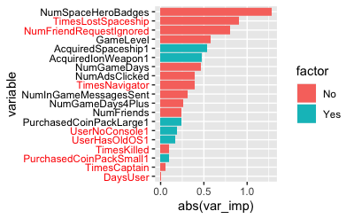

```r
cg_organic_train <- cg_organic[sample_train_org,]
cg_organic_test <- cg_organic[-sample_train_org,]

lrm <- glm(converted ~ ., family=binomial(logit), data=cg_organic_train)
# plot_model(lrm, show.values = TRUE, transform = NULL)
# plot_model(lrm, show.values = TRUE, transform = NULL, type = "eff")
varimp.logistic(lrm) %>% plotimp.logistic()
```

What is the training/test split?

```r
tot_rows <- nrow(cg_organic_train) + nrow(cg_organic_test)
paste(
   "Training Data: ", percent(nrow(cg_organic_train) / tot_rows),
   "Test Data: ", percent(nrow(cg_organic_test) / tot_rows))
```

```
[1] "Training Data:  70% Test Data:  30%"
```

2. Train a logistic regression model using all features
   1. What are the 5 most important features?

```r
varimp.logistic(lrm) %>%
   mutate(abs_var_imp=(abs(var_imp))) %>%
   arrange(desc(abs_var_imp)) %>%
   select(variable, factor, abs_var_imp, var_imp) %>%
   slice(0:5)
```

| variable | factor | abs_var_imp | var_imp |
| --- | --- | --- | --- |
| NumSpaceHeroBadges | No | 1.280 | 1.280 |
| TimesLostSpaceship | No | 0.910 | -0.910 |
| NumFriendRequestIgnored | No | 0.805 | -0.805 |
| GameLevel | No | 0.577 | 0.577 |
| AcquiredSpaceship1 | Yes | 0.538 | 0.538 |

2. For each feature of the top 5, summarize what you learn from marginal effect plots for those variables.

```r
"
1. NumSpaceHeroBadges: [POS] - As number of space hero badges go up, probability of
   conversion goes up almost to 100% (S-shaped)
2. TimesLostSpaceship: [NEG] - As # of times lost spaceship goes up, probability of
   conversion goes down from 4% to almost 0%
3. NumFriendRequestIgnored: [NEG] - As number of friend requests ignored goes up,
   probability of conversion does down
4. GameLevel: [POS] - As Game Level goes up, so does probability - from 2% to 5%+
5. AcquiredSpaceship1: [POS] - Yes/No: If Acquired Spacehip, probability jumps from ~3% to ~5%
"
```

[output not shown]

3. Plot the gains curve in the test sample and report the AUC of the model.

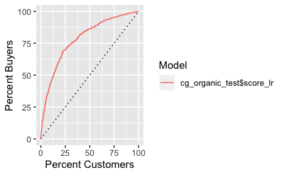

```r
cg_organic_test <- cg_organic_test %>% mutate(score_lr = predict(lrm, newdata=cg_organic_test, type="response"))

gplot <- gainsplot(cg_organic_test$score_lr, label.var = cg_organic_test$converted)
```

```r
paste("AUC: ", gplot$auc)
```

```
[1] "AUC:  0.803"
```